# Data Analysis, A tutorial

by LIN, WAN-CHING

# About Me

R&D at III, 資安所 智慧技術中心 智慧邊際運算組  
GitHub: https://github.com/wanching  
E-mail: wanchinglin@iii.org.tw

# Overview

1. Introduction
   - 介紹資料分析相關套件
2. Implementation
   - 一些套件的用法
3. Case

# Introduction

介紹資料分析相關套件

[figure not shown]

Ref: http://chdoig.github.io/ep2015-blaze/#/

[figure not shown]

Ref: http://chdoig.github.io/ep2015-blaze/#/

# Python 資料分析相關套件

[figure not shown]

Ref: https://activewizards.com/blog/top-15-libraries-for-data-science-in-python/

# Implementation

一些套件的用法

# Numpy

支援高階大量的維度陣列與矩陣運算，此外也針對陣列運算提供大量的數學函式函式庫。

# Numpy 屬性

## ndarray (N-dimensional array)

- `ndim`: 維度
- `shape`: 行數和列數
- `size`: 元素個數

[figure not shown]

# Numpy屬性

```python
# 引入 numpy 模組
import numpy as np
np1 = np.array([[1,2,3],[2,3,4]]) # list轉成矩陣
print(np1)

# 顯示相關訊息
print('np1 number of dim:', np1.ndim)  # 維度
print('np1 shape :', np1.shape) # 行數和列數
print('np1 size:', np1.size) # 元素個數
```

```
[[1 2 3]
 [2 3 4]]
np1 number of dim: 2
np1 shape : (2, 3)
np1 size: 6
```

# Numpy 基本運算(1)

```python
import numpy as np
a = np.array([10,20,30,40])
b = np.arange(4)

print('a= ', a)
print('b= ', b)

print('a+b= ', a+b)
print('a-b= ', a-b)
print('a*b= ', a*b)
print('b**2= ', b**2)
print('10*np.sin(a)= ', 10*np.sin(a))
```

```
a=  [10 20 30 40]
b=  [0 1 2 3]
a+b=  [10 21 32 43]
a-b=  [10 19 28 37]
a*b=  [  0  20  60 120]
b**2=  [0 1 4 9]
10*np.sin(a)=  [-5.44021111  9.12945251 -9.88031624  7.4511316 ]
```

Ref: http://www.numpy.org/

# Numpy 基本運算(2)

```python
import numpy as np
A = np.arange(3,14)
print('A=', A)
```

```
A= [ 3  4  5  6  7  8  9 10 11 12 13]
```

```python
A = np.arange(3,15).reshape((3,4))
print('A=', A)
print('A[1][1]= ', A[1][1])
print(A.sum(axis=1))
```

```
A= [[ 3  4  5  6]
 [ 7  8  9 10]
 [11 12 13 14]]
A[1][1]=  8
[18 34 50]
```

[figure not shown]

Ref: http://pages.physics.cornell.edu/~myers/teaching/ComputationalMethods/python/arrays.html

# Pandas

基於Numpy的一個套件，不論在讀取或處理資料都很簡單且方便

# Pandas基本介紹

- Numpy 和 Pandas有什麼不同？
  - Numpy 是array形式的，沒有欄位名稱或標籤
  - Pandas 基於Numpy構建的，有列表的標籤
- 主要有兩個資料結構
  - Series
  - DataFrame

# Series

```python
import pandas as pd
import numpy as np
a = pd.Series([1,2,4,np.nan,1])
print(a)
```

```
0    1.0
1    2.0
2    4.0
3    NaN
4    1.0
dtype: float64
```

`Series`的表現形式為：左邊索引，右邊為值  
因為我們沒指定索引，所以它會自己建立0到N-1(N為長度)的整數型索引

# DataFrame

```python
import pandas as pd
import numpy as np

dates = pd.date_range('20160101',periods=6)
df = pd.DataFrame(np.random.randn(6,4),index=dates,columns=['a','b','c','d'])

print(df)
```

```
                   a         b         c         d
2016-01-01  0.626148  0.276924 -0.057152 -1.231409
2016-01-02  1.199111  1.725236  0.456273  2.350759
2016-01-03  0.993157 -2.108354 -1.401421  1.305804
2016-01-04 -1.411956  0.876656 -3.858380 -0.304684
2016-01-05  0.974309  0.075325 -1.426059 -1.336222
2016-01-06  0.831480 -0.776678  1.880107  1.693091
```

`Dataframe`為一個表格型的資料結構，既有行索引也有列索引，可被看成由`Series`組成的大集合  
https://www.jianshu.com/p/214798dd8f93

```python
import pandas as pd
import numpy as np

df2 = pd.DataFrame({'A' : np.random.rand(4),
                    'B' : pd.Timestamp('20130102'),
                    'C' : pd.Series(1,index=list(range(4)),dtype='float32'),
                    'D' : np.array([3] * 4,dtype='int32'),
                    'E' : pd.Categorical(["test","train","test","train"]),
                    'F' : 'foo'})

print(df2)
# print(df2.dtypes) # 資料類型
# print(df2.columns) # 資料名稱
# print(df2.describe()) # 資料的總結
# print(df2.T) # transpose
# print(df2.sort_values(by='A'))
```

```
          A          B    C  D      E    F
0  0.683989 2013-01-02  1.0  3   test  foo
1  0.684026 2013-01-02  1.0  3  train  foo
2  0.023853 2013-01-02  1.0  3   test  foo
3  0.642294 2013-01-02  1.0  3  train  foo
```

# Dataframe的loc(根據標籤)

```python
dates = pd.date_range('20130101', periods=6)
df = pd.DataFrame(np.arange(24).reshape((6,4)),index=dates, columns=['A','B','C','D'])

print(df)
print(df.loc['20130102'])
print(df.loc[:,['A','B']])
print(df.loc['20130102',['A','B']])
```

```
             A   B   C   D
2013-01-01   0   1   2   3
2013-01-02   4   5   6   7
2013-01-03   8   9  10  11
2013-01-04  12  13  14  15
2013-01-05  16  17  18  19
2013-01-06  20  21  22  23
A    4
B    5
C    6
D    7
Name: 2013-01-02 00:00:00, dtype: int64
             A   B
2013-01-01   0   1
2013-01-02   4   5
2013-01-03   8   9
2013-01-04  12  13
2013-01-05  16  17
2013-01-06  20  21
A    4
B    5
Name: 2013-01-02 00:00:00, dtype: int64
```

# Dataframe的iloc(根據序列)

```python
dates = pd.date_range('20130101', periods=6)
df = pd.DataFrame(np.arange(24).reshape((6,4)),index=dates, columns=['A','B','C','D'])

print(df)
print(df.iloc[3,1])
print(df.iloc[3:5,1:3])
print(df.iloc[[1,3,5],1:3])
```

```
             A   B   C   D
2013-01-01   0   1   2   3
2013-01-02   4   5   6   7
2013-01-03   8   9  10  11
2013-01-04  12  13  14  15
2013-01-05  16  17  18  19
2013-01-06  20  21  22  23
13
             B   C
2013-01-04  13  14
2013-01-05  17  18
             B   C
2013-01-02   5   6
2013-01-04  13  14
2013-01-06  21  22
```

# Dataframe的Boolean indexing

```python
dates = pd.date_range('20130101', periods=6)
df = pd.DataFrame(np.arange(24).reshape((6,4)),index=dates, columns=['A','B','C','D'])

print(df)
print(df[df.A>8])
```

```
             A   B   C   D
2013-01-01   0   1   2   3
2013-01-02   4   5   6   7
2013-01-03   8   9  10  11
2013-01-04  12  13  14  15
2013-01-05  16  17  18  19
2013-01-06  20  21  22  23
             A   B   C   D
2013-01-04  12  13  14  15
2013-01-05  16  17  18  19
2013-01-06  20  21  22  23
```

# Pandas I/O

[figure not shown]

Ref: https://pandas.pydata.org/pandas-docs/stable/io.html

# Pandas load csv

```python
import pandas as pd

data = pd.read_csv('student.csv')
print(data)

data.to_pickle('student.pickle')
```

```
    Student ID  name   age  gender
0         1100  Kelly   22  Female
1         1101    Clo   21  Female
2         1102  Tilly   22  Female
3         1103   Tony   24    Male
4         1104  David   20    Male
5         1105  Catty   22  Female
6         1106      M    3  Female
7         1107      N   43    Male
8         1108      A   13    Male
9         1109      S   12    Male
10        1110  David   33    Male
11        1111     Dw    3  Female
12        1112      Q   23    Male
13        1113      W   21  Female
```

# Scikit-learn

適合想要使用Python實作機器學習的初學者，提供許多演算法，包含監督式、非監督式...等

[figure not shown]

Ref: http://speech.ee.ntu.edu.tw/~tlkagk/courses/ML_2017_2/Lecture/policy.pdf

[figure not shown]

Ref: http://speech.ee.ntu.edu.tw/~tlkagk/courses/ML_2017_2/Lecture/policy.pdf

[figure not shown]

Ref: http://speech.ee.ntu.edu.tw/~tlkagk/courses/ML_2017_2/Lecture/policy.pdf

# 範例：The digits dataset

- http://scikit-learn.org/stable/auto_examples/datasets/plot_digits_last_image.html

## 1. 載入手寫數字資料

```python
# 這行是在ipython notebook的介面裏專用，如果在其他介面則可以拿掉
%matplotlib inline
from sklearn import datasets, svm, metrics

import matplotlib.pyplot as plt

# 載入數字資料集
digits = datasets.load_digits()

for key, value in digits.items():
    try:
        print(key, value.shape)
    except:
        print(key)
```

```
data (1797, 64)
target (1797,)
target_names (10,)
images (1797, 8, 8)
DESCR
```

[figure not shown]

每張影像所對照的實際數字存在`digits.target`變數中

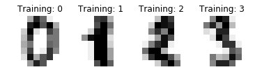

```python
images_and_labels = list(zip(digits.images, digits.target))
for index, (image, label) in enumerate(images_and_labels[:4]):
    plt.subplot(2, 4, index + 1)
    plt.axis('off')
    plt.imshow(image, cmap=plt.cm.gray_r, interpolation='nearest')
    plt.title('Training: %i' % label)
```

## 2. 訓練以及分類

```python
n_samples = len(digits.images)

# 資料攤平:1797 x 8 x 8 -> 1797 x 64
# 這裏的-1代表自動計算，相當於 (n_samples, 64)
data = digits.images.reshape((n_samples, -1))

# 產生SVC分類器
classifier = svm.SVC(gamma=0.001)

# 用前半部份的資料來訓練
classifier.fit(data[:n_samples // 2], digits.target[:n_samples // 2])

expected = digits.target[n_samples // 2:]

#利用後半部份的資料來測試分類器，共 899筆資料
predicted = classifier.predict(data[n_samples // 2:])

print("expected前10個值＝ ", expected[:10])
print("predicted前10個值＝ ", predicted[:10])
```

```
expected前10個值＝  [8 8 4 9 0 8 9 8 1 2]
predicted前10個值＝  [8 8 4 9 0 8 9 8 1 2]
```

## 3. 分類準確度統計

- 使用Confusion matrix(混淆矩陣)來統計
- `metrics.confusion_matrix(真實資料:899, 預測資料:899)`

```python
print("Confusion matrix:\n%s"
    % metrics.confusion_matrix(expected, predicted))
```

```
Confusion matrix:
[[87  0  0  0  1  0  0  0  0  0]
 [ 0 88  1  0  0  0  0  0  1  1]
 [ 0  0 85  1  0  0  0  0  0  0]
 [ 0  0  0 79  0  3  0  4  5  0]
 [ 0  0  0  0 88  0  0  0  0  4]
 [ 0  0  0  0  0 88  1  0  0  2]
 [ 0  1  0  0  0  0 90  0  0  0]
 [ 0  0  0  0  0  1  0 88  0  0]
 [ 0  0  0  0  0  0  0  0 88  0]
 [ 0  0  0  1  0  1  0  0  0 90]]
```

由矩陣可以看出，實際為3時，有數次誤判為5,7,8。

### Confusion matrix (圖示)

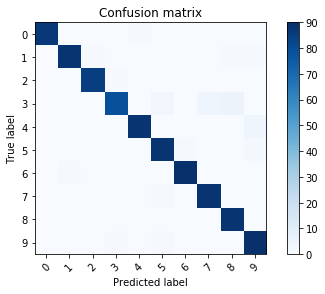

```python
def plot_confusion_matrix(cm, title='Confusion matrix', cmap=plt.cm.Blues):
    import numpy as np
    plt.imshow(cm, interpolation='nearest', cmap=cmap)
    plt.title(title)
    plt.colorbar()
    tick_marks = np.arange(len(digits.target_names))
    plt.xticks(tick_marks, digits.target_names, rotation=45)
    plt.yticks(tick_marks, digits.target_names)
    plt.tight_layout()
    plt.ylabel('True label')
    plt.xlabel('Predicted label')

plt.figure()
plot_confusion_matrix(metrics.confusion_matrix(expected, predicted))
```

### Confusion matrix (以手寫3為例)

[figure not shown]

### Confusion Matrix 統計數據

- `metrics.classification_report(expected, predicted)`

```python
print("Classification report for classifier %s:\n%s\n"
    % (classifier, metrics.classification_report(expected, predicted)))
```

```
Classification report for classifier SVC(C=1.0, cache_size=200, class_weight=None, coef0=0.0,
  decision_function_shape='ovr', degree=3, gamma=0.001, kernel='rbf',
  max_iter=-1, probability=False, random_state=None, shrinking=True,
  tol=0.001, verbose=False):
             precision    recall  f1-score   support

          0       1.00      0.99      0.99        88
          1       0.99      0.97      0.98        91
          2       0.99      0.99      0.99        86
          3       0.98      0.87      0.92        91
          4       0.99      0.96      0.97        92
          5       0.95      0.97      0.96        91
          6       0.99      0.99      0.99        91
          7       0.96      0.99      0.97        89
          8       0.94      1.00      0.97        88
          9       0.93      0.98      0.95        92

avg / total       0.97      0.97      0.97       899
```

### 觀察測試影像以及預測(分類)結果得對應關係

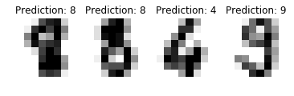

```python
images_and_predictions = list(
                        zip(digits.images[n_samples // 2:], predicted))
for index, (image, prediction) in enumerate(images_and_predictions[:4]):
    plt.subplot(2, 4, index + 5)
    plt.axis('off')
    plt.imshow(image, cmap=plt.cm.gray_r, interpolation='nearest')
    plt.title('Prediction: %i' % prediction)
```

手寫字辨識完整程式碼：http://scikit-learn.org/stable/_downloads/plot_digits_classification.py

學習推薦：

- 莫須Python: https://morvanzhou.github.io/
- 李宏毅教授: https://www.youtube.com/channel/UC2ggjtuuWvxrHHHiaDH1dlQ/playlists

Thanks for listening!